# BANA 7052 Final Project Code Appendix - Group 3

Authors

Hart Williams

Anusk Bhandari

Riley Lamport

Brian Arthur

```r
library(conflicted)   # Resolve conflicts between libraries
library(readxl)       # To read Excel file
library(tidyverse)
library(plotly)       # For plots
library(patchwork)    # For plots
library(GGally)       # For plots
library(car)          # For linear model
library(tidyr)        # For plots
library(ggplot2)      # For plots
library(pROC)         # Plot ROC curve
conflict_prefer("filter", "dplyr")
```

```
[conflicted] Will prefer dplyr::filter over any other package.
```

```r
conflict_prefer("lag", "dplyr")
```

```
[conflicted] Will prefer dplyr::lag over any other package.
```

```r
conflict_prefer("select", "dplyr")
```

```
[conflicted] Will prefer dplyr::select over any other package.
```

```r
conflict_scout()   # lists any remaining unresolved conflicts
```

```
5 conflicts
• `filter()`: dplyr
• `lag()`: dplyr
• `layout()`: plotly and graphics
• `recode()`: car and dplyr
• `some()`: car and purrr
```

```r
set.seed(7052)
raisin <- read_excel("Raisin_Dataset.xlsx")
```

# Initial Data Inspection

```r
dim(raisin)
```

```
[1] 900   8
```

```r
head(raisin)
```

```
# A tibble: 6 × 8
   Area MajorAxisLength MinorAxisLength Eccentricity ConvexArea Extent Perimeter
  <dbl>           <dbl>           <dbl>        <dbl>      <dbl>  <dbl>     <dbl>
1 87524            442.            253.        0.820      90546  0.759     1184.
2 75166            407.            243.        0.802      78789  0.684     1122.
3 90856            442.            266.        0.798      93717  0.638     1209.
4 45928            287.            209.        0.685      47336  0.700      844.
5 79408            352.            291.        0.564      81463  0.793     1073.
6 49242            318.            200.        0.777      51368  0.658      882.
# ℹ 1 more variable: Class <chr>
```

```r
str(raisin)
```

```
tibble [900 × 8] (S3: tbl_df/tbl/data.frame)
 $ Area           : num [1:900] 87524 75166 90856 45928 79408 ...
 $ MajorAxisLength: num [1:900] 442 407 442 287 352 ...
 $ MinorAxisLength: num [1:900] 253 243 266 209 291 ...
 $ Eccentricity   : num [1:900] 0.82 0.802 0.798 0.685 0.564 ...
 $ ConvexArea     : num [1:900] 90546 78789 93717 47336 81463 ...
 $ Extent         : num [1:900] 0.759 0.684 0.638 0.7 0.793 ...
 $ Perimeter      : num [1:900] 1184 1122 1209 844 1073 ...
 $ Class          : chr [1:900] "Kecimen" "Kecimen" "Kecimen" "Kecimen" ...
```

```r
glimpse(raisin)
```

```
Rows: 900
Columns: 8
$ Area            <dbl> 87524, 75166, 90856, 45928, 79408, 49242, 42492, 60952…
$ MajorAxisLength <dbl> 442.2460, 406.6907, 442.2670, 286.5406, 352.1908, 318.…
$ MinorAxisLength <dbl> 253.2912, 243.0324, 266.3283, 208.7600, 290.8275, 200.…
$ Eccentricity    <dbl> 0.8197384, 0.8018052, 0.7983536, 0.6849892, 0.5640113,…
$ ConvexArea      <dbl> 90546, 78789, 93717, 47336, 81463, 51368, 43904, 62329…
$ Extent          <dbl> 0.7586506, 0.6841296, 0.6376128, 0.6995994, 0.7927719,…
$ Perimeter       <dbl> 1184.040, 1121.786, 1208.575, 844.162, 1073.251, 881.8…
$ Class           <chr> "Kecimen", "Kecimen", "Kecimen", "Kecimen", "Kecimen",…
```

```r
summary(raisin)
```

```
      Area        MajorAxisLength MinorAxisLength  Eccentricity
 Min.   : 25387   Min.   :225.6   Min.   :143.7   Min.   :0.3487
 1st Qu.: 59348   1st Qu.:345.4   1st Qu.:219.1   1st Qu.:0.7418
 Median : 78902   Median :407.8   Median :247.8   Median :0.7988
 Mean   : 87804   Mean   :430.9   Mean   :254.5   Mean   :0.7815
 3rd Qu.:105028   3rd Qu.:494.2   3rd Qu.:279.9   3rd Qu.:0.8426
 Max.   :235047   Max.   :997.3   Max.   :492.3   Max.   :0.9621
   ConvexArea         Extent         Perimeter            Class
 Min.   : 26139   Min.   :0.3799   Min.   : 619.1   Length   :900
 1st Qu.: 61513   1st Qu.:0.6709   1st Qu.: 966.4   N.unique :  2
 Median : 81651   Median :0.7074   Median :1119.5   N.blank  :  0
 Mean   : 91186   Mean   :0.6995   Mean   :1165.9   Min.nchar:  5
 3rd Qu.:108376   3rd Qu.:0.7350   3rd Qu.:1308.4   Max.nchar:  7
 Max.   :278217   Max.   :0.8355   Max.   :2697.8
```

# Data Overview and Quality

The dataset contains 900 raisin observations and eight variables: seven numerical measurements and one categorical variable, `Class`, identifying the raisin as either Besni or Kecimen.

We check the distribution of the two classes, missing values, duplicate observations, and the ranges of the numerical variables.

```r
raisin$Class <- as.factor(raisin$Class)

levels(raisin$Class)
```

```
[1] "Besni"   "Kecimen"
```

```r
table(raisin$Class)
```

```
  Besni Kecimen
    450     450
```

```r
colSums(is.na(raisin))
```

```
           Area MajorAxisLength MinorAxisLength    Eccentricity      ConvexArea
              0               0               0               0               0
         Extent       Perimeter           Class
              0               0               0
```

```r
sum(duplicated(raisin))
```

```
[1] 0
```

```r
summary(raisin)
```

```
      Area        MajorAxisLength MinorAxisLength  Eccentricity
 Min.   : 25387   Min.   :225.6   Min.   :143.7   Min.   :0.3487
 1st Qu.: 59348   1st Qu.:345.4   1st Qu.:219.1   1st Qu.:0.7418
 Median : 78902   Median :407.8   Median :247.8   Median :0.7988
 Mean   : 87804   Mean   :430.9   Mean   :254.5   Mean   :0.7815
 3rd Qu.:105028   3rd Qu.:494.2   3rd Qu.:279.9   3rd Qu.:0.8426
 Max.   :235047   Max.   :997.3   Max.   :492.3   Max.   :0.9621
   ConvexArea         Extent         Perimeter          Class
 Min.   : 26139   Min.   :0.3799   Min.   : 619.1   Besni  :450
 1st Qu.: 61513   1st Qu.:0.6709   1st Qu.: 966.4   Kecimen:450
 Median : 81651   Median :0.7074   Median :1119.5
 Mean   : 91186   Mean   :0.6995   Mean   :1165.9
 3rd Qu.:108376   3rd Qu.:0.7350   3rd Qu.:1308.4
 Max.   :278217   Max.   :0.8355   Max.   :2697.8
```

The two raisin varieties are equally represented, with 450 observations from each class. No missing values or duplicate observations were found. In addition, the numerical summaries do not indicate impossible values such as negative areas or axis lengths.

# ————————————————–

# Descriptive Statistics by Raisin Variety

To compare the two raisin varieties, summary statistics are calculated separately for Besni and Kecimen raisins. Particular attention is given to Area, Major Axis Length, and Minor Axis Length because these variables are central to the proposed regression model.

```r
raisin %>%
  group_by(Class) %>%
  summarise(
    n = n(),

    mean_area = mean(Area),
    sd_area = sd(Area),
    median_area = median(Area),

    mean_major_axis = mean(MajorAxisLength),
    sd_major_axis = sd(MajorAxisLength),

    mean_minor_axis = mean(MinorAxisLength),
    sd_minor_axis = sd(MinorAxisLength)
  )
```

```
# A tibble: 2 × 9
  Class       n mean_area sd_area median_area mean_major_axis sd_major_axis
  <fct>   <int>     <dbl>   <dbl>       <dbl>           <dbl>         <dbl>
1 Besni     450   112195.  39230.     104426.            509.         106.
2 Kecimen   450    63413.  17728.      61420             353.          59.6
# ℹ 2 more variables: mean_minor_axis <dbl>, sd_minor_axis <dbl>
```

The descriptive statistics show noticeable differences in size between the two raisin varieties. Besni raisins have a substantially larger mean Area than Kecimen raisins. Besni raisins also have a larger average Major Axis Length.

The larger standard deviations observed for Besni raisins suggest that Besni raisins also exhibit greater variability in size. These differences indicate that raisin variety may be important when explaining variation in Area.

# Distribution of Area

Because Area will serve as the response variable in the regression model, its distribution is examined both overall and separately by raisin variety.

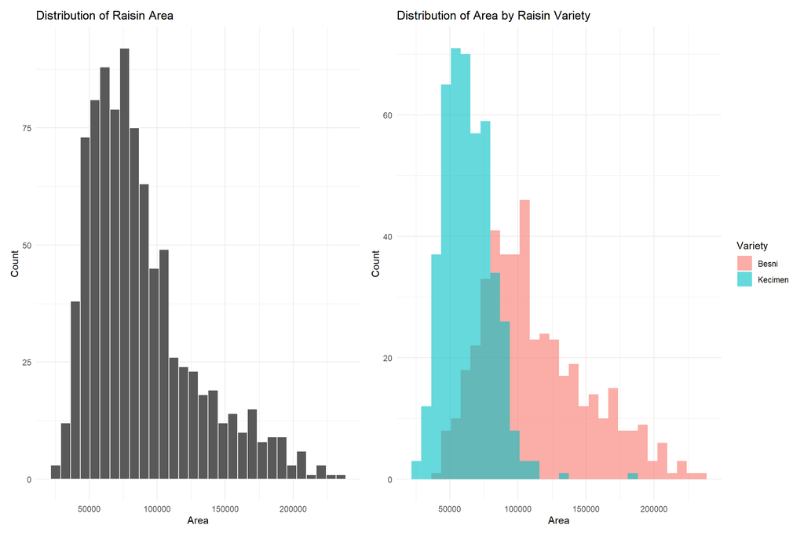

```r
p <- ggplot(raisin, aes(x = Area)) +
  geom_histogram(
    bins = 30,
    color = "white"
  ) +
  labs(
    title = "Distribution of Raisin Area",
    x = "Area",
    y = "Count"
  ) +
  theme_minimal()

p_class <- ggplot(raisin, aes(x = Area, fill = Class)) +
  geom_histogram(
    bins = 30,
    alpha = 0.6,
    position = "identity"
  ) +
  labs(
    title = "Distribution of Area by Raisin Variety",
    x = "Area",
    y = "Count",
    fill = "Variety"
  ) +
  theme_minimal()

p + p_class
```

The overall distribution of raisin Area appears right-skewed, with several observations having substantially larger areas than most of the dataset.

Separating the distribution by Class shows noticeable differences between Besni and Kecimen raisins. Besni raisins tend to have larger areas, although some overlap exists between the two distributions. This provides initial evidence that `Class` may help explain variation in Area.

# Comparison of Key Measurements by Raisin Variety

Boxplots are used to compare the distributions of Area, Major Axis Length, and Minor Axis Length between Besni and Kecimen raisins.

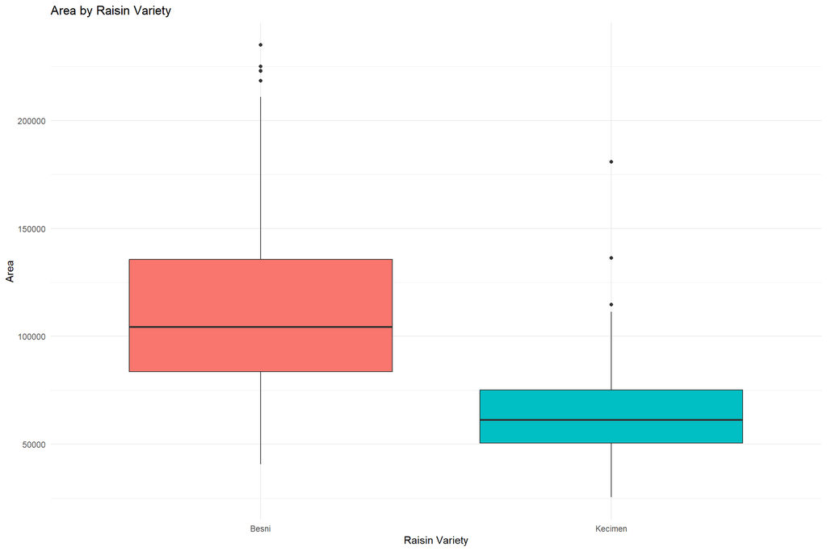

```r
p_area <- ggplot(
  raisin,
  aes(x = Class, y = Area, fill = Class)
) +
  geom_boxplot() +
  labs(
    title = "Area by Raisin Variety",
    x = "Raisin Variety",
    y = "Area"
  ) +
  theme_minimal() +
  theme(legend.position = "none")

p_major <- ggplot(
  raisin,
  aes(x = Class, y = MajorAxisLength, fill = Class)
) +
  geom_boxplot() +
  labs(
    title = "Major Axis Length by Raisin Variety",
    x = "Raisin Variety",
    y = "Major Axis Length"
  ) +
  theme_minimal() +
  theme(legend.position = "none")

p_minor <- ggplot(
  raisin,
  aes(x = Class, y = MinorAxisLength, fill = Class)
) +
  geom_boxplot() +
  labs(
    title = "Minor Axis Length by Raisin Variety",
    x = "Raisin Variety",
    y = "Minor Axis Length"
  ) +
  theme_minimal() +
  theme(legend.position = "none")

p_area
```

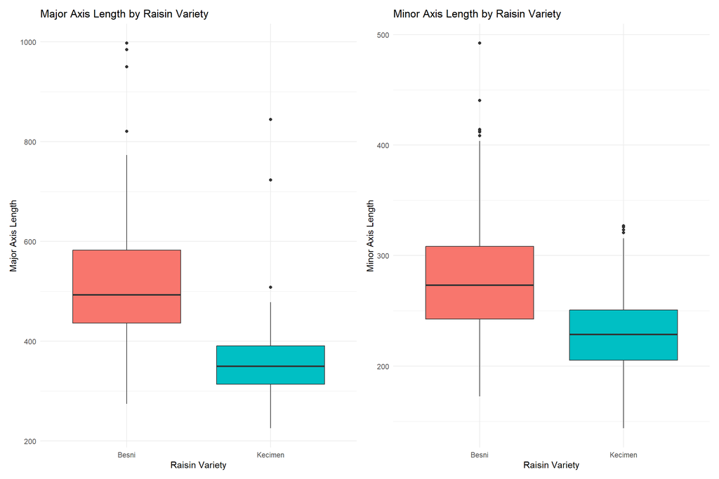

```r
p_major + p_minor
```

The boxplots show systematic size differences between the two raisin varieties. Besni raisins generally have larger Area and axis-length measurements, while Kecimen raisins tend to have smaller measurements.

Several potential outliers are visible, especially among the larger observations. These observations are retained because unusual observations are not necessarily errors. Their influence can be examined later during regression diagnostics.

# Relationships Between Measurement variables and Area

To investigate which measurements are associated with Area, each numerical predictor is plotted against Area.

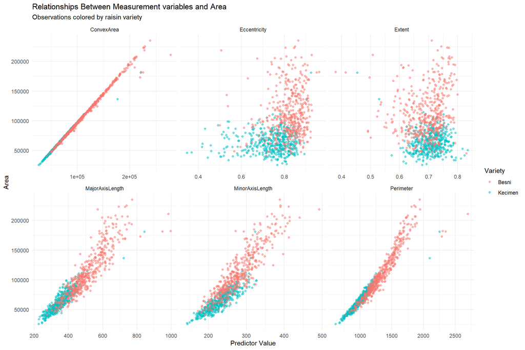

```r
df_long_area <- pivot_longer(
  raisin,
  cols = -c(Class, Area),
  names_to = "variable",
  values_to = "value"
)

ggplot(
  df_long_area,
  aes(
    x = value,
    y = Area,
    color = Class
  )
) +
  geom_point(alpha = 0.5) +
  facet_wrap(
    ~ variable,
    scales = "free_x"
  ) +
  labs(
    title = "Relationships Between Measurement variables and Area",
    subtitle = "Observations colored by raisin variety",
    x = "Predictor Value",
    y = "Area",
    color = "Variety"
  ) +
  theme_minimal()
```

The scatterplots show that several size-related are strongly associated with Area.

Major Axis Length, Minor Axis Length, Convex Area, and Perimeter show clear positive relationships with Area. Eccentricity and Extent appear to have weaker relationships with Area.

The separation between Besni and Kecimen observations in several plots also suggests that raisin variety may contribute information beyond the individual numerical measurements.

# Major Axis Length and Area

Investigating Major Axis Length as it is one of the primary predictors proposed for the regression model:

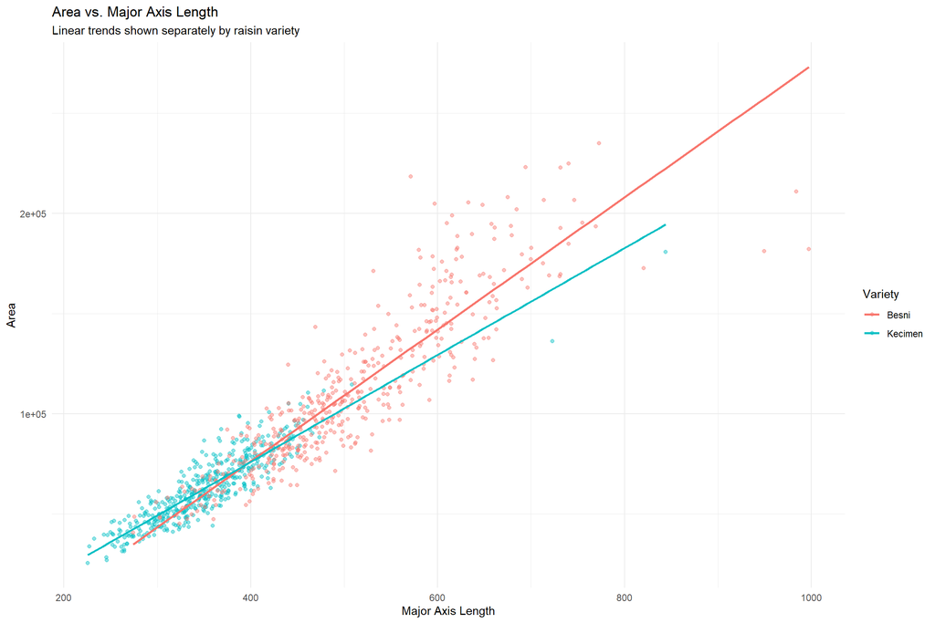

```r
ggplot(
  raisin,
  aes(
    x = MajorAxisLength,
    y = Area,
    color = Class
  )
) +
  geom_point(alpha = 0.45) +
  geom_smooth(
    method = "lm",
    se = FALSE
  ) +
  labs(
    title = "Area vs. Major Axis Length",
    subtitle = "Linear trends shown separately by raisin variety",
    x = "Major Axis Length",
    y = "Area",
    color = "Variety"
  ) +
  theme_minimal()
```

Area increases as Major Axis Length increases for both varieties.

Differences in the fitted slopes would motivate formally testing an interaction between `Class` and `MajorAxisLength` in the regression model.

# Minor Axis Length and Area

The relationship between Minor Axis Length and Area is also examined separately by raisin variety.

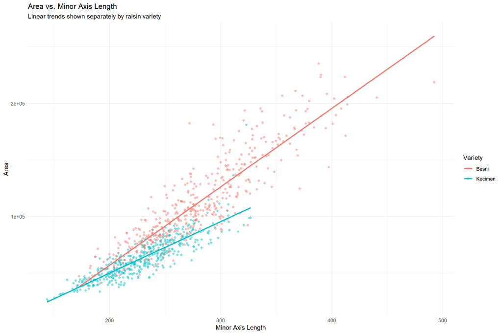

```r
ggplot(
  raisin,
  aes(
    x = MinorAxisLength,
    y = Area,
    color = Class
  )
) +
  geom_point(alpha = 0.45) +
  geom_smooth(
    method = "lm",
    se = FALSE
  ) +
  labs(
    title = "Area vs. Minor Axis Length",
    subtitle = "Linear trends shown separately by raisin variety",
    x = "Minor Axis Length",
    y = "Area",
    color = "Variety"
  ) +
  theme_minimal()
```

Area also increases with Minor Axis Length.

# Distribution of Measurement variables by Class

Density plots are used to compare the distributions of all numerical measurements between Besni and Kecimen raisins.

These plots help identify which measurements differ most strongly between the two varieties.

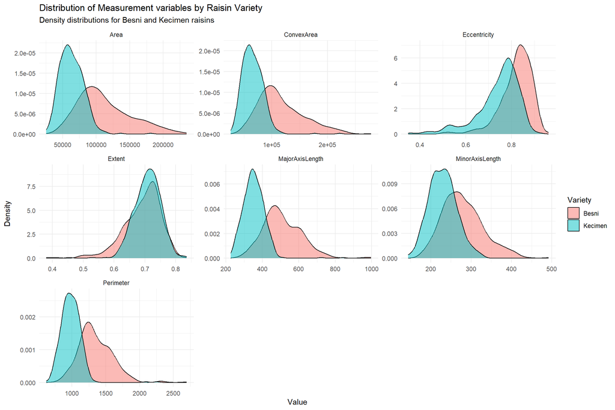

```r
df_long <- pivot_longer(
  raisin,
  cols = -Class,
  names_to = "variable",
  values_to = "value"
)

ggplot(
  df_long,
  aes(
    x = value,
    fill = Class
  )
) +
  geom_density(alpha = 0.5) +
  facet_wrap(
    ~ variable,
    scales = "free"
  ) +
  labs(
    title = "Distribution of Measurement variables by Raisin Variety",
    subtitle = "Density distributions for Besni and Kecimen raisins",
    x = "Value",
    y = "Density",
    fill = "Variety"
  ) +
  theme_minimal()
```

The density plots indicate that some measurement varaibles provide greater separation between the two raisin varieties than others.

Size-related variables such as Area and the axis-length measurements show noticeable differences between Besni and Kecimen raisins, although substantial overlap remains.

The overlap suggests that no single measurement completely separates the two varieties.

# Correlation Among Numerical Variables

A correlation matrix is used to examine relationships among the numerical measurements.

```r
numeric_data <- raisin %>%
  select(where(is.numeric))

round(
  cor(numeric_data),
  2
)
```

```
                 Area MajorAxisLength MinorAxisLength Eccentricity ConvexArea
Area             1.00            0.93            0.91         0.34       1.00
MajorAxisLength  0.93            1.00            0.73         0.58       0.95
MinorAxisLength  0.91            0.73            1.00        -0.03       0.90
Eccentricity     0.34            0.58           -0.03         1.00       0.35
ConvexArea       1.00            0.95            0.90         0.35       1.00
Extent          -0.01           -0.20            0.15        -0.36      -0.05
Perimeter        0.96            0.98            0.83         0.45       0.98
                Extent Perimeter
Area             -0.01      0.96
MajorAxisLength  -0.20      0.98
MinorAxisLength   0.15      0.83
Eccentricity     -0.36      0.45
ConvexArea       -0.05      0.98
Extent            1.00     -0.17
Perimeter        -0.17      1.00
```

Several size-related variables are strongly correlated with one another, particularly Area, Convex Area, Perimeter, and the axis-length measurements.

These relationships are expected because the variables represent related aspects of raisin size and shape. However, strong correlations among predictors may also lead to multicollinearity in a multiple linear regression model. This should be evaluated later during model fitting.

# Combined Axis Measurement

Because raisin Area is related to both its length and width, the product of Major Axis Length and Minor Axis Length is also explored.

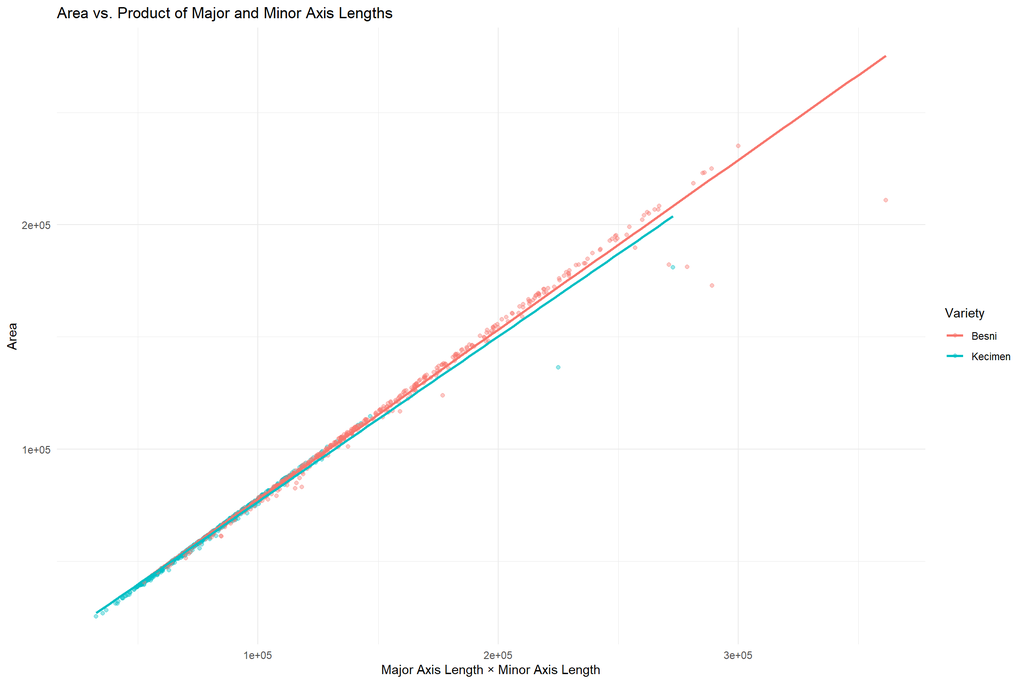

```r
ggplot(
  raisin,
  aes(
    x = MajorAxisLength * MinorAxisLength,
    y = Area,
    color = Class
  )
) +
  geom_point(alpha = 0.4) +
  geom_smooth(
    method = "lm",
    se = FALSE
  ) +
  labs(
    title = "Area vs. Product of Major and Minor Axis Lengths",
    x = "Major Axis Length × Minor Axis Length",
    y = "Area",
    color = "Variety"
  ) +
  theme_minimal()
```

This exploratory plot evaluates whether combining both dimensions produces a particularly strong relationship with Area.

# EDA Summary

Overall, the exploratory analysis suggests that raisin size and shape differ meaningfully between the Besni and Kecimen varieties.

Area is strongly associated with several size-related measurements, particularly Major Axis Length, Minor Axis Length, Convex Area, and Perimeter. The distributions of several measurements also differ noticeably between classes.

These findings support the proposed use of Area as the response variable and Major Axis Length, Minor Axis Length, and Class as explanatory variables.

The class-specific patterns in the scatterplots also motivate investigating interactions between Class and axis length to determine whether the relationship between raisin dimensions and Area differs by variety.

The exploratory analysis also identifies two issues that should be evaluated during regression modeling: possible nonlinearity between Area and the size measurements, and potential multicollinearity among highly correlated predictors.

# ————————————————–

# Model Objective

The objective of this analysis is to develop a multiple linear regression model to predict raisin Area using geometric measurements and raisin variety. Building on the exploratory data analysis, the initial model includes Major Axis Length, Minor Axis Length, Eccentricity, Extent, Perimeter, and Class. The Raisin Dataset contains 900 observations, which were divided into 720 training observations (80%) and 180 testing observations (20%). A reproducible random split was generated in R using set.seed(7052). Two main model specifications were evaluated: an initial additive regression model and an improved model incorporating an interaction between Major Axis Length and Minor Axis Length. A separate comparison model included ConvexArea to evaluate the predictive contribution of an additional area-related measurement.

```r
set.seed(7052)

train_id <- sample(
  seq_len(nrow(raisin)),
  size = floor(0.8 * nrow(raisin))
)

train <- raisin[train_id, ]
test <- raisin[-train_id, ]

cat("Training observations:", nrow(train), "\n")
```

```
Training observations: 720
```

```r
cat("Testing observations:", nrow(test), "\n")
```

```
Testing observations: 180
```

# Initial Linear Regression Model

The primary regression model is: Area = β₀ + β₁*MajorAxisLength + β₂*MinorAxisLength + β₃*Eccentricity + β₄*Extent + β₅*Perimeter + β₆*Class + ε

```r
model1 <- lm(
  Area ~ MajorAxisLength + MinorAxisLength + Eccentricity +
    Extent + Perimeter + Class,
  data=train
)

cat("\nInitial Model Summary:\n")
```

```
Initial Model Summary:
```

```r
print(summary(model1))
```

```
Call:
lm(formula = Area ~ MajorAxisLength + MinorAxisLength + Eccentricity +
    Extent + Perimeter + Class, data = train)

Residuals:
   Min     1Q Median     3Q    Max
-14840  -3366  -1325   2207  22865

Coefficients:
                  Estimate Std. Error t value Pr(>|t|)
(Intercept)     -1.153e+05  4.867e+03 -23.685  < 2e-16 ***
MajorAxisLength  2.666e+02  1.291e+01  20.643  < 2e-16 ***
MinorAxisLength  4.584e+02  1.282e+01  35.768  < 2e-16 ***
Eccentricity     1.623e+04  4.487e+03   3.617 0.000319 ***
Extent           1.335e+04  4.346e+03   3.072 0.002206 **
Perimeter       -4.370e+01  6.249e+00  -6.993 6.18e-12 ***
ClassKecimen     1.003e+03  5.227e+02   1.919 0.055355 .
---
Signif. codes:  0 '***' 0.001 '**' 0.01 '*' 0.05 '.' 0.1 ' ' 1

Residual standard error: 5016 on 713 degrees of freedom
Multiple R-squared:  0.9836,    Adjusted R-squared:  0.9835
F-statistic:  7139 on 6 and 713 DF,  p-value: < 2.2e-16
```

```r
cat("\nInitial Model Confidence Intervals:\n")
```

```
Initial Model Confidence Intervals:
```

```r
print(confint(model1))
```

```
                        2.5 %        97.5 %
(Intercept)     -124837.30638 -105725.38804
MajorAxisLength     241.24847     291.96153
MinorAxisLength     433.26405     483.59032
Eccentricity       7418.78307   25035.50394
Extent             4819.95431   21886.85074
Perimeter           -55.97472     -31.43551
ClassKecimen        -23.03437    2029.28335
```

Major Axis Length and Minor Axis Length were positively associated with Area after controlling for the other predictors. Eccentricity and Extent also showed statistically significant positive associations. Perimeter had a negative coefficient despite its positive relationship with Area in the exploratory analysis. This suggests that correlations among geometric measurements may affect the estimated individual predictor effects. Class was not statistically significant at the 5% level (p = 0.0554).

# Initial Model Performance

Predictive performance was evaluated on the 180 held-out testing observations using R², Root Mean Squared Error (RMSE), and Mean Absolute Error (MAE).

```r
model2 <- lm(
  Area ~ MajorAxisLength + MinorAxisLength + Eccentricity +
    Extent + Perimeter + ConvexArea + Class,
  data = train
)

cat("\nConvex Area Model Summary:\n")
```

```
Convex Area Model Summary:
```

```r
print(summary(model2))
```

```
Call:
lm(formula = Area ~ MajorAxisLength + MinorAxisLength + Eccentricity +
    Extent + Perimeter + ConvexArea + Class, data = train)

Residuals:
     Min       1Q   Median       3Q      Max
-23843.0   -932.6    -63.9    825.1   9648.6

Coefficients:
                  Estimate Std. Error t value Pr(>|t|)
(Intercept)     -1.463e+04  2.413e+03  -6.064 2.16e-09 ***
MajorAxisLength  9.955e+01  5.542e+00  17.962  < 2e-16 ***
MinorAxisLength  1.560e+02  6.739e+00  23.146  < 2e-16 ***
Eccentricity     1.516e+04  1.706e+03   8.888  < 2e-16 ***
Extent           2.449e+03  1.661e+03   1.475    0.141
Perimeter       -6.742e+01  2.404e+00 -28.051  < 2e-16 ***
ConvexArea       9.372e-01  1.442e-02  64.975  < 2e-16 ***
ClassKecimen    -1.063e+03  2.012e+02  -5.282 1.70e-07 ***
---
Signif. codes:  0 '***' 0.001 '**' 0.01 '*' 0.05 '.' 0.1 ' ' 1

Residual standard error: 1907 on 712 degrees of freedom
Multiple R-squared:  0.9976,    Adjusted R-squared:  0.9976
F-statistic: 4.295e+04 on 7 and 712 DF,  p-value: < 2.2e-16
```

```r
pred1 <- predict(model1, newdata = test)
pred2 <- predict(model2, newdata = test)


evaluate <- function(actual, predicted) {
  c(
    R2 = 1 - sum((actual - predicted)^2) /
      sum((actual - mean(actual))^2),
    RMSE = sqrt(mean((actual - predicted)^2)),
    MAE = mean(abs(actual - predicted))
  )
}


initial_comparison <- rbind(
  "Without ConvexArea" = evaluate(test$Area, pred1),
  "With ConvexArea" = evaluate(test$Area, pred2)
)

cat("\nInitial Model Comparison:\n")
```

```
Initial Model Comparison:
```

```r
print(round(initial_comparison, 4))
```

```
                       R2     RMSE      MAE
Without ConvexArea 0.9843 4872.946 3640.485
With ConvexArea    0.9976 1919.779 1155.686
```

The model without ConvexArea explained approximately 98.43% of the variation in Area relative to the test-set mean. Including ConvexArea improved predictive accuracy substantially, reducing RMSE to 1,919.779.

However, ConvexArea is closely related to the response variable by definition. Therefore, models excluding ConvexArea provide a more informative assessment of prediction using other geometric measurements.

# Out-of-Sample Prediction Error Graph

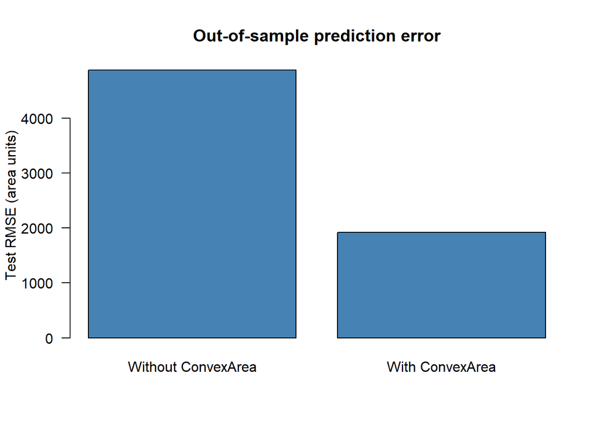

```r
barplot(
  initial_comparison[, "RMSE"],
  main = "Out-of-sample prediction error",
  ylab = "Test RMSE (area units)",
  col = "steelblue",
  las = 1
)
```

# Initial Regression Diagnostics

Four diagnostic plots were examined to evaluate the assumptions of the initial regression model. The Residuals-versus-Fitted plot displayed a clear U-shaped pattern, suggesting that the additive linear model did not adequately capture the nonlinear relationship between raisin dimensions and Area. The Normal Q–Q plot showed departures from the reference line, indicating deviations from residual normality. The Scale-Location plot showed changing residual variability across fitted values, suggesting heteroscedasticity. The Residuals-versus-Leverage plot also identified potentially influential observations. Variance Inflation Factors (VIF) revealed substantial multicollinearity, particularly for Perimeter (83.68), Major Axis Length (64.85), and Minor Axis Length (11.80). These results suggested that several predictors contained overlapping information.

# Initial Regression Diagnostics — Four Graphs

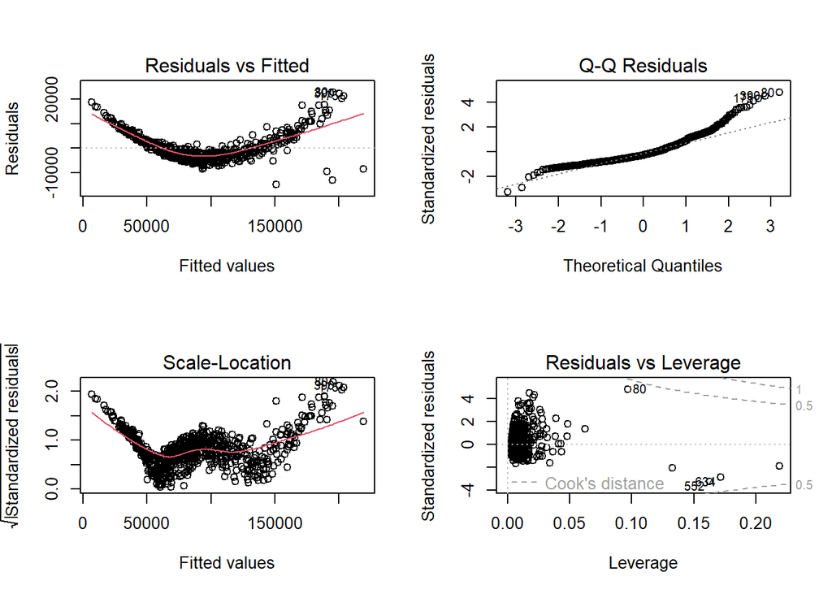

```r
par(mfrow = c(2, 2))

plot(model1)
```

```r
par(mfrow = c(1, 1))

cat("\nInitial Model VIF:\n")
```

```
Initial Model VIF:
```

```r
print(vif(model1))
```

```
MajorAxisLength MinorAxisLength    Eccentricity          Extent       Perimeter
      64.853177       11.799201        4.773423        1.513081       83.675635
          Class
       1.954623
```

These diagnostic findings motivated the development of an improved regression model.

# Uncentered Interaction Model

```r
model4 <- lm(
  Area ~ MajorAxisLength * MinorAxisLength +
    Eccentricity + Extent + Class,
  data = train
)

cat("\nUncentered Interaction Model:\n")
```

```
Uncentered Interaction Model:
```

```r
print(summary(model4))
```

```
Call:
lm(formula = Area ~ MajorAxisLength * MinorAxisLength + Eccentricity +
    Extent + Class, data = train)

Residuals:
   Min     1Q Median     3Q    Max
-50818   -879    -42    950  10065

Coefficients:
                                  Estimate Std. Error t value Pr(>|t|)
(Intercept)                     -4.161e+04  3.415e+03 -12.184   <2e-16 ***
MajorAxisLength                 -7.907e+00  5.719e+00  -1.383   0.1672
MinorAxisLength                  9.272e+01  9.703e+00   9.556   <2e-16 ***
Eccentricity                     2.337e+04  2.565e+03   9.110   <2e-16 ***
Extent                           2.022e+04  2.334e+03   8.665   <2e-16 ***
ClassKecimen                    -7.291e+02  3.066e+02  -2.378   0.0177 *
MajorAxisLength:MinorAxisLength  6.783e-01  1.725e-02  39.312   <2e-16 ***
---
Signif. codes:  0 '***' 0.001 '**' 0.01 '*' 0.05 '.' 0.1 ' ' 1

Residual standard error: 2913 on 713 degrees of freedom
Multiple R-squared:  0.9945,    Adjusted R-squared:  0.9944
F-statistic: 2.14e+04 on 6 and 713 DF,  p-value: < 2.2e-16
```

```r
pred4 <- predict(model4, newdata = test)

cat("\nUncentered Interaction Test Results:\n")
```

```
Uncentered Interaction Test Results:
```

```r
print(round(evaluate(test$Area, pred4), 4))
```

```
       R2      RMSE       MAE
   0.9909 3702.3568 1563.0116
```

# Final Centered Interaction Model

```r
major_mean <- mean(train$MajorAxisLength)
minor_mean <- mean(train$MinorAxisLength)

train$Major_c <- train$MajorAxisLength - major_mean
train$Minor_c <- train$MinorAxisLength - minor_mean

test$Major_c <- test$MajorAxisLength - major_mean
test$Minor_c <- test$MinorAxisLength - minor_mean

model5 <- lm(
  Area ~ Major_c * Minor_c +
    Eccentricity + Extent + Class,
  data = train
)

cat("\nFinal Centered Model Summary:\n")
```

```
Final Centered Model Summary:
```

```r
print(summary(model5))
```

```
Call:
lm(formula = Area ~ Major_c * Minor_c + Eccentricity + Extent +
    Class, data = train)

Residuals:
   Min     1Q Median     3Q    Max
-50818   -879    -42    950  10065

Coefficients:
                  Estimate Std. Error t value Pr(>|t|)
(Intercept)      5.306e+04  2.481e+03  21.390   <2e-16 ***
Major_c          1.648e+02  3.028e+00  54.422   <2e-16 ***
Minor_c          3.853e+02  5.729e+00  67.249   <2e-16 ***
Eccentricity     2.337e+04  2.565e+03   9.110   <2e-16 ***
Extent           2.022e+04  2.334e+03   8.665   <2e-16 ***
ClassKecimen    -7.291e+02  3.066e+02  -2.378   0.0177 *
Major_c:Minor_c  6.783e-01  1.725e-02  39.312   <2e-16 ***
---
Signif. codes:  0 '***' 0.001 '**' 0.01 '*' 0.05 '.' 0.1 ' ' 1

Residual standard error: 2913 on 713 degrees of freedom
Multiple R-squared:  0.9945,    Adjusted R-squared:  0.9944
F-statistic: 2.14e+04 on 6 and 713 DF,  p-value: < 2.2e-16
```

```r
cat("\nFinal Model Confidence Intervals:\n")
```

```
Final Model Confidence Intervals:
```

```r
print(confint(model5))
```

```
                        2.5 %        97.5 %
(Intercept)     48192.8411851 57933.9164060
Major_c           158.8223494   170.7104487
Minor_c           374.0244906   396.5202115
Eccentricity    18330.3959453 28401.7420699
Extent          15640.9336855 24805.5033175
ClassKecimen    -1330.9733395  -127.2206210
Major_c:Minor_c     0.6443903     0.7121368
```

```r
cat("\nFinal Model GVIF:\n")
```

```
Final Model GVIF:
```

```r
print(vif(model5, type = "predictor"))
```

```
GVIFs computed for predictors
```

```
                 GVIF Df GVIF^(1/(2*Df)) Interacts With
Major_c      7.950515  3        1.412752        Minor_c
Minor_c      7.950515  3        1.412752        Major_c
Eccentricity 4.624478  1        2.150460           --
Extent       1.293258  1        1.137215           --
Class        1.993225  1        1.411816           --
                                   Other Predictors
Major_c                 Eccentricity, Extent, Class
Minor_c                 Eccentricity, Extent, Class
Eccentricity        Major_c, Minor_c, Extent, Class
Extent        Major_c, Minor_c, Eccentricity, Class
Class        Major_c, Minor_c, Eccentricity, Extent
```

To address the nonlinear residual pattern and reduce redundancy among predictors, Perimeter was removed and an interaction between Major Axis Length and Minor Axis Length was introduced. The axis measurements were centered by subtracting their respective training-sample means.

The improved model was specified as:

Area = β₀ + β₁(Major_c) + β₂(Minor_c) + β₃(Major_c × Minor_c) + β₄(Eccentricity) + β₅(Extent) + β₆(Class) + ε

The improved model achieved a training R² of 0.9945 and an adjusted R² of 0.9944.

# ————————————————–

## GLM

```r
rm(raisin)
data <- read_excel("Raisin_Dataset.xlsx")
set.seed(7052)
```

# Train-test stratified split

```r
# Get 720 observations (80%) to train and 180 (20%) to test

besni_idx   <- which(data$Class == "Besni")
kecimen_idx <- which(data$Class == "Kecimen")

train_idx <- c(sample(besni_idx,   size = 0.8 * length(besni_idx)),
               sample(kecimen_idx, size = 0.8 * length(kecimen_idx)))

train <- data[train_idx, ]
test  <- data[-train_idx, ]

nrow(train); nrow(test)
```

```
[1] 720
```

```
[1] 180
```

```r
table(train$Class); table(test$Class)
```

```
  Besni Kecimen
    360     360
```

```
  Besni Kecimen
     90      90
```

# Correlation Matrix

```r
attach(train)

# Variables with correlations near 0.9 or higher are carrying nearly the same information, so keep one from each such group
cor(train[, names(train) != "Class"])
```

```
                       Area MajorAxisLength MinorAxisLength Eccentricity
Area            1.000000000       0.9319667      0.90728175   0.33692608
MajorAxisLength 0.931966661       1.0000000      0.72681899   0.58875071
MinorAxisLength 0.907281751       0.7268190      1.00000000  -0.02572418
Eccentricity    0.336926076       0.5887507     -0.02572418   1.00000000
ConvexArea      0.996307683       0.9429992      0.89696085   0.34836183
Extent          0.001334214      -0.1834657      0.15085121  -0.34885880
Perimeter       0.962537626       0.9771504      0.82938364   0.45085811
                 ConvexArea       Extent  Perimeter
Area             0.99630768  0.001334214  0.9625376
MajorAxisLength  0.94299921 -0.183465712  0.9771504
MinorAxisLength  0.89696085  0.150851208  0.8293836
Eccentricity     0.34836183 -0.348858797  0.4508581
ConvexArea       1.00000000 -0.036711622  0.9764322
Extent          -0.03671162  1.000000000 -0.1539898
Perimeter        0.97643220 -0.153989824  1.0000000
```

# Test Different Predictors

```r
# Area strongly collinear with 4 predictors, so skip
# Convex Area strongly collinear with both axes, so skip
# Perimeter strongly collinear with major axis, so skip

train$is_besni <- ifelse(train$Class == "Besni", 1, 0)
gfit <- glm(is_besni ~ MajorAxisLength + MinorAxisLength + Eccentricity + Extent, family=binomial, data=train)
coef(summary(gfit))
```

```
                    Estimate  Std. Error    z value     Pr(>|z|)
(Intercept)     -7.509392958 4.427668447 -1.6960152 8.988300e-02
MajorAxisLength  0.026771276 0.006868717  3.8975656 9.716449e-05
MinorAxisLength  0.001424824 0.011269274  0.1264344 8.993881e-01
Eccentricity    -0.879781906 5.051873931 -0.1741496 8.617479e-01
Extent          -4.612835431 2.792433936 -1.6519049 9.855393e-02
```

```r
# MinorAxisLength had the largest p-value, so leave out
gfit <- glm(is_besni ~ MajorAxisLength + Eccentricity + Extent, family=binomial, data=train)
coef(summary(gfit))
```

```
                   Estimate  Std. Error    z value     Pr(>|z|)
(Intercept)     -7.05648799 2.578477625 -2.7366877 6.206118e-03
MajorAxisLength  0.02759048 0.002307272 11.9580500 5.892952e-33
Eccentricity    -1.47823277 1.725171705 -0.8568612 3.915216e-01
Extent          -4.56446865 2.767054656 -1.6495766 9.902956e-02
```

```r
# Eccentricity had the largest p-value, so leave out
gfit <- glm(is_besni ~ MajorAxisLength + Extent, family=binomial, data=train)
coef(summary(gfit))
```

```
                   Estimate  Std. Error   z value     Pr(>|z|)
(Intercept)     -8.41661933 2.032520500 -4.140976 3.458306e-05
MajorAxisLength  0.02671228 0.002032164 13.144746 1.824164e-39
Extent          -3.76325263 2.586330433 -1.455055 1.456541e-01
```

# Compare two models

```r
# Extent's coefficient had p=0.1457 (Wald test), indicating Extent is not significant at the 0.05 level
# Can still compare with single-predictor model

fit_big <- gfit  # Rename fit for comparison
fit_small <- glm(is_besni ~ MajorAxisLength, family=binomial, data=train)

anova(fit_small, fit_big, test = "Chisq")   # Does adding Extent significntly improve the fit?
```

```
Analysis of Deviance Table

Model 1: is_besni ~ MajorAxisLength
Model 2: is_besni ~ MajorAxisLength + Extent
  Resid. Df Resid. Dev Df Deviance Pr(>Chi)
1       718     528.73
2       717     526.58  1   2.1497   0.1426
```

```r
AIC(fit_small, fit_big)   # lower is better
```

```
          df      AIC
fit_small  2 532.7250
fit_big    3 532.5754
```

# Coefficients for chosen model

```r
gfit <- fit_small
rm(fit_big)
rm(fit_small)

coef(summary(gfit))
```

```
                    Estimate Std. Error   z value     Pr(>|z|)
(Intercept)     -11.17565829 0.83211229 -13.43047 4.008648e-41
MajorAxisLength   0.02700633 0.00203405  13.27712 3.142291e-40
```

The estimated coefficients are β₀ = -11.1757,and β₁ (MajorAxisLength) = 0.0270. According to the Wald test, MajorAxisLength is significant at the α = 0.05 level. The fitted model is:

log(p / (1 − p)) = −11.1757 + 0.027·MajorAxisLength

where p is the probability that a raisin is Besni.

# Odds ratio & confidence interval

```r
exp(coef(gfit))      # odds ratio
```

```
    (Intercept) MajorAxisLength
   1.401113e-05    1.027374e+00
```

```r
exp(confint(gfit))   # 95% confidence interval for the odds ratio
```

```
                       2.5 %       97.5 %
(Intercept)     2.521584e-06 6.614514e-05
MajorAxisLength 1.023487e+00 1.031693e+00
```

```r
# A 1-pixel change is tiny, so rescale to 10 pixels
or10 <- exp(10 * coef(gfit)["MajorAxisLength"])
or10
```

```
MajorAxisLength
       1.310047
```

```r
ci <- confint(gfit)
exp(10 * ci["MajorAxisLength", ])   # 95% CI per 10 pixels
```

```
   2.5 %   97.5 %
1.261320 1.366167
```

```r
print("Percent increase in odds per 10 pixels:")
```

```
[1] "Percent increase in odds per 10 pixels:"
```

```r
(or10 - 1) * 100
```

```
MajorAxisLength
       31.00474
```

- Each 1-pixel increase in MajorAxisLength multiplies the odds of a raisin being Besni by 1.027, or about 1.31 for each 10-pixel increase (95% CI [1.26, 1.37]), which corresponds with about a 31% increase in the odds.
- Since the interval excludes 1, longer raisins are significantly more likely to be Besni.

# Example probabilities

```r
lengths <- quantile(data$MajorAxisLength, c(0.25, 0.5, 0.75))

new_vals <- data.frame(MajorAxisLength = lengths)
new_vals$prob_besni <- predict(gfit, newdata = new_vals, type = "response")
new_vals
```

```
    MajorAxisLength prob_besni
25%        345.4429  0.1362829
50%        407.8040  0.4594968
75%        494.1870  0.8975709
```

# Confusion matrix

```r
test$is_besni  <- ifelse(test$Class  == "Besni", 1, 0)

# predicted probability of Besni for the unseen raisins
p_hat <- predict(gfit, newdata = test, type = "response")

# classify using a 0.5 cutoff
pred_class <- ifelse(p_hat > 0.5, 1, 0)

# confusion matrix
cm <- table(Predicted = factor(pred_class, levels = c(0, 1)),
            Actual    = factor(test$is_besni, levels = c(0, 1)))
cm
```

```
         Actual
Predicted  0  1
        0 76 13
        1 14 77
```

```r
# summary metrics
accuracy    <- sum(diag(cm)) / sum(cm)
sensitivity <- cm["1", "1"] / sum(cm[, "1"])   # Besni correctly identified
specificity <- cm["0", "0"] / sum(cm[, "0"])   # Kecimen correctly identified

accuracy; sensitivity; specificity
```

```
[1] 0.85
```

```
[1] 0.8555556
```

```
[1] 0.8444444
```

Confusion matrix metrics (0.5 cutoff, 180 test raisins, 90 per variety):

- Accuracy: (76 + 77) / 180 = 153/180 = 0.850
- Sensitivity (Besni correctly identified): 77/90 = 0.856
- Specificity (Kecimen correctly identified): 76/90 = 0.844

# ROC Curve, AOC

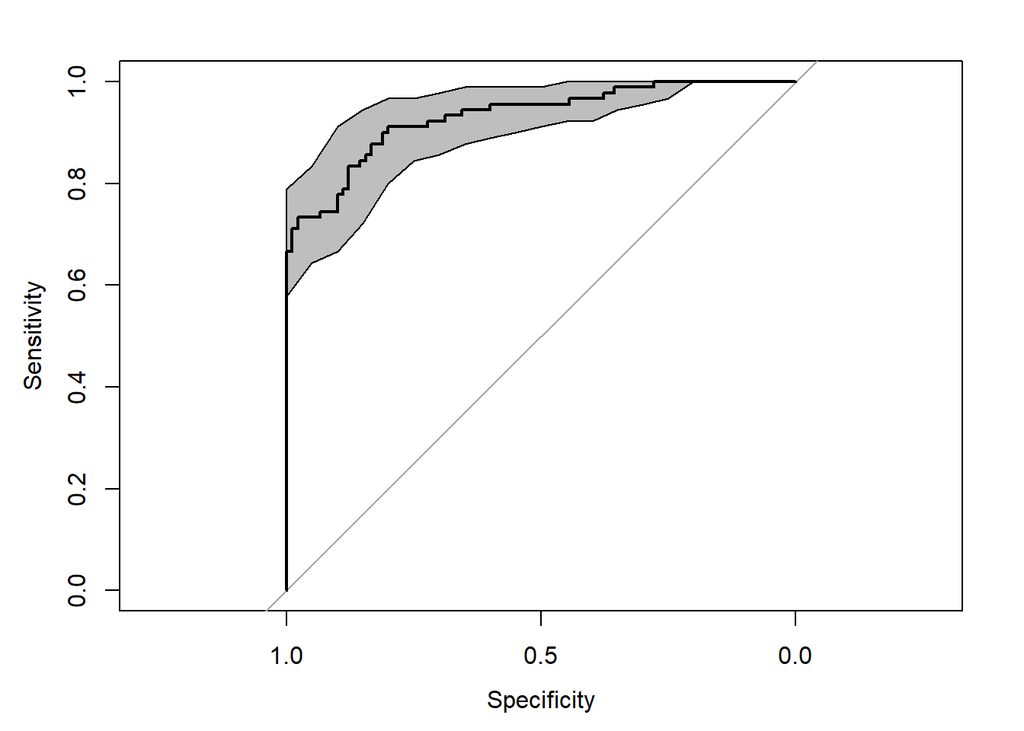

```r
roc_obj <- roc(test$is_besni, p_hat)
plot(roc_obj)
plot(ci.se(roc_obj, specificities = seq(0, 1, 0.05)), type = "shape", col = "grey")
```

```r
auc(roc_obj)
```

```
Area under the curve: 0.9317
```

```r
ci.auc(roc_obj)
```

```
95% CI: 0.8963-0.9671 (DeLong)
```

- The ROC curve, which summarizes sensitivity and specificity across all possible cutoffs, rises well above the diagonal line representing random guessing.
- The area under the curve (AUC) is 0.932 (95% CI [0.896, 0.967]), meaning that for a randomly chosen Besni and Kecimen raisin, the model assigns a higher probability of Besni to the actual Besni raisin about 93% of the time.
- This indicates excellent discrimination using MajorAxisLength alone, and it answers our research question: a raisin’s variety can be predicted fairly well from a single size measurement.

# ————————————————–

## Contribution statement

- Hart Williams: Presented GLM | Completed GLM, compiled code appendix, found chosen dataset
- Anusk Bhandari: Presented EDA | Completed Data Inspection & EDA
- Riley Lamport: Presented Overview & Conclusion | Developed slides, communicated & verified requirements
- Brian Arthur: Presented Linear Model | Completed Linear Model